### [BIC30007 - *Sequence Alignment Fundamentals, Algorithm, and Application*](http://ugm.id/BIC30007practical02)

# 02.2 *Dot Plot Method*

## Pengantar

Pada tutorial sebelumnya, kita telah mengaplikasikan pensejajaran sekuen untuk identifikasi spesies (DNA Barcoding). Pensejajaran sekuen baru dengan sekuen biologis yang telah diketahui dapat memberikan gambaran mengenai fungsi dan asal-usul evolusionernya. Pada tutorial ini, kita akan mempelajari prinsip dan teknik komputasi yang digunakan untuk melakukan dan mengevaluasi pensejajaran sekuen.

## 1. Dot Plot

Metode Dot Plot digunakan untuk melakukan perbandingan visual antara dua sekuen (*pairwise alignment*). Pada contoh yang paling sederhana, 2 sekuen dibandingkan dengan menggunakan matrix, dimana satu sekuen berada pada sumbu vertikal, dan satunya lagi pada sumbu horizontal. Saat terjadi kesamaan *(match)* pada posisi horizontal, maka sebuah titik akan dibuat.

[figure not shown]

Metode dotplot yang lebih kompleks menggunakan **"sliding windows"** dan **"threshold value"** untuk menentukan apakah sebuah segmen dari kedua sekuen yang dibandingkan memiliki kesamaan atau tidak.

```python
# load Library
from IPython.display import Image
```

### 1.1 Analisis struktur gen: Ekson dan Intron

Kita dapat mempelajari struktur ekson dan intron dari sebuah gen secara visual dengan menggunakan EMBOSS - dotmatcher.

Pada script di bawah, kita akan membandingkan struktur bagian genom Arabidopsis (AT3G52905.1) dengan salah satu cDNA:

**PS: karakter "!" di depan berarti bahwa script berjalan di terminal**

```
Draw a threshold dotplot of two sequences
Created 01_AT3G4905.1.png
```

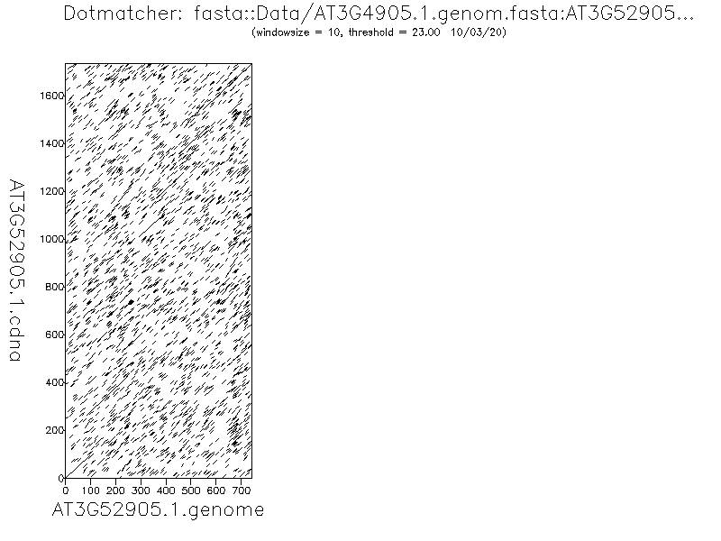

```python
# jika EMBOSS belum terinstall, silahkan install terlebih dahulu dengan mengetik pada terminal:
# conda install -c bioconda emboss
! dotmatcher Data/AT3G4905.1.genom.fasta Data/AT3G4905.1.cdna.fasta -graph png -goutfile 01_AT3G4905
Image(filename='01_AT3G4905.1.png')
```

#### Diskusi

- Mengapa banyak *"noise"* yang muncul pada dot plot di atas?
- Parameter apa yang dapat kita gunakan untuk memperbaiki tampilan dot plot di atas?

Coba jalankan script di bawah ini:

```
Draw a threshold dotplot of two sequences
Created 02_AT3G4905_strict.1.png
```

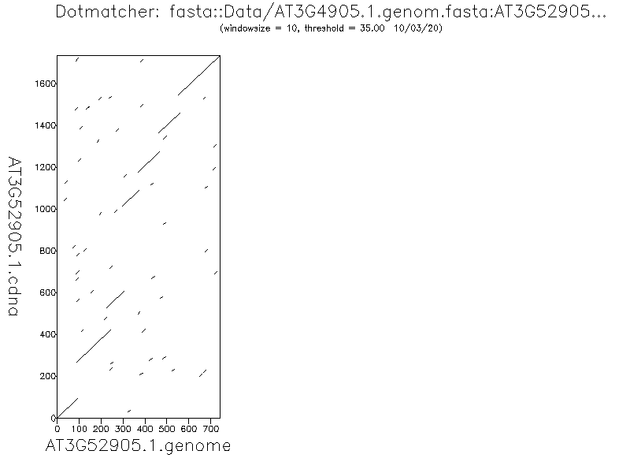

```python
! dotmatcher -windowsize 10 -threshold 35 Data/AT3G4905.1.genom.fasta Data/AT3G4905.1.cdna.fasta -graph png -goutfile 02_AT3G4905_strict
Image(filename='02_AT3G4905_strict.1.png')
```

#### Diskusi

- Coba cari tahu apa yang dimaksud dengan *"window size"* dan *"threshold value"*!
- Kenapa garis diagonal utama terpisah menjadi beberapa fragmen?

### 1.2 Membandingkan gen yang berkerabat dekat

```
Draw a threshold dotplot of two sequences
Created 03_CDKL4.1.png
```

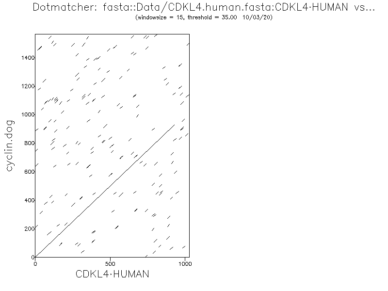

```python
! dotmatcher -windowsize 15 -threshold 35 Data/CDKL4.human.fasta Data/cyclin.dog.fasta -graph png -goutfile 03_CDKL4
Image(filename='03_CDKL4.1.png')
```

#### Diskusi

- Apakah terdapat kemiripan antara CDS manusia dan anjing?
- Mengapa sebagian region DNA/genom memiliki kemiripan yang tinggi meskipun berasal dari spesies yang berbeda?

Selanjutnya, kita akan mencoba membandingkan sekuen mRNA dari α dan β-globin

```
Draw a threshold dotplot of two sequences
Created 04_globin.1.png
```

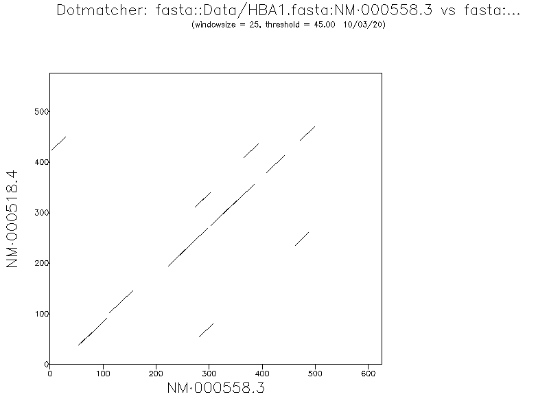

```python
! dotmatcher -windowsize 25 -threshold 45 Data/HBA1.fasta Data/HBB.fasta -graph png -goutfile 04_globin
Image(filename='04_globin.1.png')
```

#### Diskusi

- Informasi apa yang dapat dijelaskan mengenai perbedaan α dan β-globin pada dot plot di atas?

### 1.3 *Tandem Repeats*

Visualisasi pensejajaran juga dapat kita gunakan untuk mempelajari bagian genom/DNA yang diulang *(repeated/inverted)*. Selanjutnya, kita akan mempelajari *repeats* dari *human zinc finger protein Q9P255*.

Sejajarkan protein dengan dirinya sendiri menggunakan script berikut:

```
Draw a threshold dotplot of two sequences
Created 05_tandem_repeats.1.png
```

[figure not shown]

```python
! dotmatcher Data/Q9P255.fasta Data/Q9P255.fasta -graph png -goutfile 05_tandem_repeats
Image(filename='05_tandem_repeats.1.png')
```

Diskusi:

- Bagaimana interpretasi dari pola yang dihasilkan?
- Bagaimanakah distribusi dari repeats yang muncul? Lebih banyak pada ujung N atau C? Ada berapa repeats yang muncul?
- Coba ubah *threshold value* dan perhatikan pengaruhnya terhadap visualisasi pensejajaran alignment!

```
Draw a threshold dotplot of two sequences
Created 05_tandem_repeats_filter.1.png
```

[figure not shown]

```python
# write your code here:

! dotmatcher -windowsize 25 -threshold 45 Data/Q9P255.fasta Data/Q9P255.fasta -graph png -goutfile 05_tandem_repeats_filter
Image(filename='05_tandem_repeats_filter.1.png')
```

#### Klik link di bawah untuk kembali ke Modul Utama:

### [BIC30007 - *Sequence Alignment Fundamentals, Algorithm, and Application*](http://ugm.id/BIC30007practical02)